# Linh Le - Fraud Detection using Autoencoders

```python
import pandas as pd
import numpy as np
import matplotlib.pyplot as plt
import seaborn as sns
%matplotlib inline
import warnings
warnings.simplefilter(action='ignore', category=FutureWarning)
data = pd.read_csv('/Users/linhle/Downloads/inpatientCharges 2.csv')
```

```python
data.columns = ['DRG','Provider_Id', 'Provider_Name','Provider_StreetAddress','Provider_City',
               'Provider_State','Provider_Zipcode','Hospital_referral_region_desp',
                'Total_Discharges','Average_Covered_Charges','Average_Total_Payments',
                'Average_Medicare_Payment']
```

```python
data['DRG'] = data['DRG'].astype('category')
data['Provider_State'] = data['Provider_State'].astype('category')
data['Provider_City'] = data['Provider_City'].astype('category')
data['Provider_Id'] = data['Provider_Id'].astype('category')
data['Average_Covered_Charges'] = (data['Average_Covered_Charges']
                              .str.replace('$', '').astype(float))
data['Average_Total_Payments'] = (data['Average_Total_Payments']
                              .str.replace('$', '').astype(float))
data['Average_Medicare_Payment'] = (data['Average_Medicare_Payment']
                              .str.replace('$', '').astype(float))
```

# Feature Engineering

## Feature 1: Average Total Payments by DRG and State

```python
feat1 = (
    data.groupby(['DRG', 'Provider_State'], as_index=False)['Average_Total_Payments']
        .mean()
        .rename(columns={'Average_Total_Payments': 'F1_AvgTotalPayment_by_DRG_State'})
)
```

## Feature 2: Average Total Payments by Total Discharges and DRG

```python
feat2 = (
    data.groupby(['Total_Discharges', 'DRG'], as_index=False)['Average_Total_Payments']
        .mean()
        .rename(columns={'Average_Total_Payments': 'F2_AvgTotalPayment_by_Discharges_DRG'})
)
```

## Feature 3: Average Medicare Payments as % of Total Payment

```python
data['F3_MedicarePct_of_Total'] = (
    data['Average_Medicare_Payment'] / data['Average_Total_Payments']
) * 100
```

## Feature 4: Average Total Payments as % of Average Covered Charges

```python
data['F4_TotalPayPct_of_Covered'] = (
    data['Average_Total_Payments'] / data['Average_Covered_Charges']
) * 100
```

## Feature 5: Average Covered Charges by Total Discharges

```python
feat5 = (
    data.groupby('Total_Discharges', as_index=False)['Average_Covered_Charges']
        .mean()
        .rename(columns={'Average_Covered_Charges': 'F5_AvgCoveredCharge_by_Discharges'})
)
```

## Feature 6: Average Covered Charges by State and DRG

```python
feat6 = (
    data.groupby(['Provider_State', 'DRG'], as_index=False)['Average_Covered_Charges']
        .mean()
        .rename(columns={'Average_Covered_Charges': 'F6_AvgCoveredCharge_by_State_DRG'})
)
```

## Feature 7: Total Payment to Covered Charges % by State and DRG

```python
feat7 = (
    data.groupby(['Provider_State', 'DRG'])
    .apply(lambda x: pd.Series({
        'F7_TotalPay_to_CoveredPct_by_State_DRG':
            (x['Average_Total_Payments'].sum() / x['Average_Covered_Charges'].sum()) * 100
    }))
    .reset_index()
)
```

```python
merged = data.copy()
merged = merged.merge(feat1, on=['DRG', 'Provider_State'], how='left')
merged = merged.merge(feat2, on=['Total_Discharges', 'DRG'], how='left')
merged = merged.merge(feat5, on='Total_Discharges', how='left')
merged = merged.merge(feat6, on=['Provider_State', 'DRG'], how='left')
merged = merged.merge(feat7, on=['Provider_State', 'DRG'], how='left')
```

```python
print("Original shape:", data.shape)
print("Merged shape:", merged.shape)
merged.head()
```

```
Original shape: (163065, 14)
Merged shape: (163065, 19)
```

|  | DRG | Provider_Id | Provider_Name | Provider_StreetAddress | Provider_City | Provider_State | Provider_Zipcode | Hospital_referral_region_desp | Total_Discharges | Average_Covered_Charges | Average_Total_Payments | Average_Medicare_Payment | F3_MedicarePct_of_Total | F4_TotalPayPct_of_Covered | F1_AvgTotalPayment_by_DRG_State | F2_AvgTotalPayment_by_Discharges_DRG | F5_AvgCoveredCharge_by_Discharges | F6_AvgCoveredCharge_by_State_DRG | F7_TotalPay_to_CoveredPct_by_State_DRG |
| --- | --- | --- | --- | --- | --- | --- | --- | --- | --- | --- | --- | --- | --- | --- | --- | --- | --- | --- | --- |
| 0 | 039 - EXTRACRANIAL PROCEDURES W/O CC/MCC | 10001 | SOUTHEAST ALABAMA MEDICAL CENTER | 1108 ROSS CLARK CIRCLE | DOTHAN | AL | 36301 | AL - Dothan | 91 | 32963.07 | 5777.24 | 4763.73 | 82.456848 | 17.526402 | 5743.611739 | 6925.716667 | 30769.406038 | 32044.436957 | 17.923897 |
| 1 | 039 - EXTRACRANIAL PROCEDURES W/O CC/MCC | 10005 | MARSHALL MEDICAL CENTER SOUTH | 2505 U S HIGHWAY 431 NORTH | BOAZ | AL | 35957 | AL - Birmingham | 14 | 15131.85 | 5787.57 | 4976.71 | 85.989629 | 38.247604 | 5743.611739 | 6702.873500 | 36758.935195 | 32044.436957 | 17.923897 |
| 2 | 039 - EXTRACRANIAL PROCEDURES W/O CC/MCC | 10006 | ELIZA COFFEE MEMORIAL HOSPITAL | 205 MARENGO STREET | FLORENCE | AL | 35631 | AL - Birmingham | 24 | 37560.37 | 5434.95 | 4453.79 | 81.947212 | 14.469905 | 5743.611739 | 6698.172500 | 38321.822994 | 32044.436957 | 17.923897 |
| 3 | 039 - EXTRACRANIAL PROCEDURES W/O CC/MCC | 10011 | ST VINCENT'S EAST | 50 MEDICAL PARK EAST DRIVE | BIRMINGHAM | AL | 35235 | AL - Birmingham | 25 | 13998.28 | 5417.56 | 4129.16 | 76.218076 | 38.701612 | 5743.611739 | 6740.903077 | 37372.408624 | 32044.436957 | 17.923897 |
| 4 | 039 - EXTRACRANIAL PROCEDURES W/O CC/MCC | 10016 | SHELBY BAPTIST MEDICAL CENTER | 1000 FIRST STREET NORTH | ALABASTER | AL | 35007 | AL - Birmingham | 18 | 31633.27 | 5658.33 | 4851.44 | 85.739785 | 17.887275 | 5743.611739 | 7211.365882 | 37233.587488 | 32044.436957 | 17.923897 |

# Autoenconder

### Autoencoders (AEs) are neural network models that learn the normal distribution of data by compressing input data into a low-dimensional representation and then reconstruct it. The encoder produces a latent space which is a set of fixed nodes that maps the input features to a low-dimensional speace. Optimization for accurate reconstruction of typical patterns allows the models to capture data's distribution and structural patterns. When new inputs deviate from the learned patterns, the higher reconstruction error indicates potential anomalies.

```python
import importlib, sys, os, inspect
import torch
```

```python
from sklearn.model_selection import train_test_split

X = merged.drop(columns=['Provider_Name', 'Provider_City', 'Provider_State', 'DRG',
                         'Average_Total_Payments'])
y = merged['Average_Total_Payments']
X_encoded = pd.get_dummies(X, drop_first=True)
```

```python
X_train, X_test, y_train, y_test = train_test_split(X_encoded, y, test_size=0.25, random_state=123)
```

**Since features scale differently, adding standardization is essential. Additionally, to address noises, applying PCA to ensure model's stability**

```python
from sklearn.preprocessing import StandardScaler
from sklearn.decomposition import PCA
from sklearn.decomposition import IncrementalPCA

scaler = StandardScaler()
X_train_scaled = scaler.fit_transform(X_train)
X_test_scaled = scaler.transform(X_test)

pca = PCA(n_components=200, random_state=42)

X_train_pca = pca.fit_transform(X_train_scaled)
X_test_pca = pca.transform(X_test_scaled)
X_train = pd.DataFrame(X_train_pca)
X_test = pd.DataFrame(X_test_pca)

pca_cols = [f'PC{i+1}' for i in range(X_train_pca.shape[1])]

X_train_pd = pd.DataFrame(X_train_pca, columns=pca_cols, index=X_train.index)
X_test_pd = pd.DataFrame(X_test_pca, columns=pca_cols, index=X_test.index)

y_train_pd = pd.Series(y_train, index=X_train.index, name='Average_Total_Payments')
y_test_pd = pd.Series(y_test, index=X_test.index, name='Average_Total_Payments')
```

```python
def count_stat(vector):
    # Because it is '0' and '1',
    # we can run a count statistic.
    unique, counts = np.unique(vector, return_counts=True)
    return dict(zip(unique.tolist(), counts.tolist()))

def descriptive_stat_threshold(df, pred_score, threshold):
    # Let's see how many '0's and '1's.
    df = pd.DataFrame(df)
    df.columns = feature_list
    df['Anomaly_Score'] = pred_score
    df['Group'] = np.where(df['Anomaly_Score']< threshold,
                 'Normal', 'Outlier')
    # Now let's show the summary statistics:
    cnt = df.groupby('Group')['Anomaly_Score'].count().reset_index().rename(columns={'Anomaly_Score':'Count'})
    # The count and count %
    cnt['Count %'] = (cnt['Count'] / cnt['Count'].sum()) * 100
    # The average
    stat = df.groupby('Group').mean().round(2).reset_index()
    # Put the count and the average together
    stat = cnt.merge(stat, left_on='Group', right_on='Group')
    return (stat)

def confusion_matrix_threshold(
    actual,score, threshold):
    Actual_pred = pd.DataFrame({'Actual': actual, 'Pred': score})
    Actual_pred['Pred'] = np.where(Actual_pred['Pred']<=threshold,0,1)
    cm = pd.crosstab(Actual_pred['Actual'],Actual_pred['Pred'])
    return (cm)

def confusion_matrix(actual,pred):
    Actual_pred = pd.DataFrame({'Actual': actual,'Pred': pred})
    cm = pd.crosstab(Actual_pred['Actual'],Actual_pred['Pred'])
    return (cm)

def plot_data():
    plt.scatter(X_train_pd[0], X_train_pd[1],c=y_train, alpha=0.8)
    plt.title('Scatter plot')
    plt.xlabel('x0')
    plt.ylabel('x1')
    plt.show()
```

[output not shown]

```python
from pyod.models.auto_encoder import AutoEncoder
atcdr = AutoEncoder(contamination=0.05, hidden_neuron_list =[5, 2])
atcdr.epochs = 3
atcdr.batch_size = 128
atcdr.verbose = 2
atcdr.fit(X_train)
```

```python
y_train_scores = atcdr.decision_function(X_train)
y_train_pred = atcdr.predict(X_train)
y_test_scores = atcdr.decision_function(X_test)
y_test_pred = atcdr.predict(X_test) # outlier labels (0 or 1)

print("The threshold for the defined contamination rate:" , atcdr.threshold_)
print("The training data:", count_stat(y_train_pred))
print("The test data:", count_stat(y_test_pred))
```

```
The threshold for the defined contamination rate: 23.981196308135985
The training data: {0: 116183, 1: 6115}
The test data: {0: 38479, 1: 2288}
```

### At 5% contamination rate, the model identifies the threshold to be at 23.981196308135985 with 6115 nomalies on the train data and 2288 on the test data. This is a relatively large number of anomalies.

```python
atcdr.get_params()
```

```
{'batch_norm': True,
 'batch_size': 128,
 'compile_mode': 'default',
 'contamination': 0.05,
 'device': device(type='cpu'),
 'dropout_rate': 0.2,
 'epoch_num': 10,
 'hidden_activation_name': 'relu',
 'hidden_neuron_list': [5, 2],
 'lr': 0.001,
 'optimizer_name': 'adam',
 'optimizer_params': {'weight_decay': 1e-05},
 'preprocessing': True,
 'random_state': 42,
 'use_compile': False,
 'verbose': 2}
```

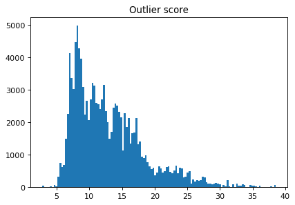

```python
plt.figure(figsize=(6, 4), dpi=80)
import matplotlib.pyplot as plt
plt.hist(y_train_scores, bins='auto') # arguments are passed to np.histogram
plt.title("Outlier score")
plt.show()
```

### By looking at the plot, it appears that the threshold is around 30

```python
manual_threshold = 30
y_train_pred_manual = (y_train_scores > manual_threshold).astype(int)
y_test_pred_manual  = (y_test_scores  > manual_threshold).astype(int)
```

```python
from collections import Counter
print("Train:", Counter(y_train_pred_manual))
print("Test :", Counter(y_test_pred_manual))
```

```
Train: Counter({0: 121106, 1: 1192})
Test : Counter({0: 40315, 1: 452})
```

### With a threshold of 30, the model identifies 1192 anomalies for train set and 452 anomalies for test set. These are still high number of anomalies. Hence, applying percentile at 99.5 may allow for more robust indentification and smaller number of anomalies. With this percentile, the model identifies a threshold of 32.66

```python
manual_threshold = np.percentile(y_train_scores, 99.5)
print("Threshold at 99.5th percentile:", manual_threshold)

y_train_pred_manual = (y_train_scores > manual_threshold).astype(int)
y_test_pred_manual  = (y_test_scores  > manual_threshold).astype(int)
```

```
Threshold at 99.5th percentile: 32.65974552154541
```

```python
threshold = 32.65974552154541

feature_list = [
    'feature_01','feature_02','feature_03','feature_04','feature_05',
    'feature_06','feature_07','feature_08','feature_09','feature_10',
    'feature_11','feature_12','feature_13','feature_14','feature_15'
]

def descriptive_stat_threshold(df, pred_score, threshold):
    import numpy as np
    import pandas as pd

    df = pd.DataFrame(df)
    # only first 15 columns
    df = df.iloc[:, :15]
    df.columns = feature_list

    df['Anomaly_Score'] = pred_score
    df['Group'] = np.where(df['Anomaly_Score'] < threshold, 'Normal', 'Outlier')

    summary = df.groupby('Group').describe().T
    print(summary)

    return df

result_df = descriptive_stat_threshold(X_train, y_train_scores, threshold)
```

```
Group                       Normal     Outlier
feature_01    count  121686.000000  612.000000
              mean        0.006144   -1.221570
              std         2.343364    1.517483
              min       -11.228029   -3.479707
              25%        -1.454493   -2.340482
...                            ...         ...
Anomaly_Score min         2.797534   32.660156
              25%         8.603994   33.546161
              50%        11.777302   34.771006
              75%        15.829515   36.153378
              max        32.659309   38.573772

[128 rows x 2 columns]
```

```python
descriptive_stat_threshold(X_test,y_test_scores, 32.65974552154541)
```

```
Group                      Normal     Outlier
feature_01    count  40502.000000  265.000000
              mean       0.008400   -0.844943
              std        2.330238    1.477106
              min       -6.825608   -3.489680
              25%       -1.435482   -1.893519
...                           ...         ...
Anomaly_Score min        2.086553   32.673027
              25%        8.446518   33.514015
              50%       11.641232   35.191032
              75%       15.863589   35.821609
              max       32.483074   39.002045

[128 rows x 2 columns]
```

|  | feature_01 | feature_02 | feature_03 | feature_04 | feature_05 | feature_06 | feature_07 | feature_08 | feature_09 | feature_10 | feature_11 | feature_12 | feature_13 | feature_14 | feature_15 | Anomaly_Score | Group |
| --- | --- | --- | --- | --- | --- | --- | --- | --- | --- | --- | --- | --- | --- | --- | --- | --- | --- |
| 0 | 0.215440 | -1.644461 | 0.845943 | -1.779988 | -0.707975 | 0.190093 | 0.053453 | -2.280841 | -1.494917 | 0.621325 | -2.469526 | -0.579102 | -1.301001 | 1.430173 | 1.126218 | 8.214823 | Normal |
| 1 | 2.176261 | 0.636100 | 2.145063 | 3.602908 | -0.683054 | 1.576827 | -3.637578 | 4.470757 | -2.265905 | -1.580677 | 1.850346 | 1.382233 | 3.033772 | 1.328871 | -3.624742 | 25.282532 | Normal |
| 2 | -2.973407 | 0.575817 | 3.418452 | 1.082280 | 1.035887 | -1.668272 | -1.594056 | -1.829357 | 0.600461 | 1.611970 | -0.190412 | -2.744049 | -2.506163 | -2.046625 | 0.000727 | 12.048306 | Normal |
| 3 | -2.281754 | -1.645668 | 0.165500 | 0.001751 | 1.449437 | 1.473779 | -0.675606 | 1.387311 | 2.270562 | 0.114479 | 0.939712 | -0.515510 | -2.513982 | -1.009741 | 0.330817 | 10.906641 | Normal |
| 4 | 6.295961 | 1.182749 | 1.567739 | 1.649799 | 0.899063 | 1.046842 | 1.428280 | 3.604686 | 1.996966 | -0.686593 | -0.690480 | -0.533173 | -0.510711 | -0.846070 | -0.180071 | 6.115070 | Normal |
| ... | ... | ... | ... | ... | ... | ... | ... | ... | ... | ... | ... | ... | ... | ... | ... | ... | ... |
| 40762 | -2.042971 | -0.390000 | -1.054997 | -1.227761 | 0.144015 | 1.868348 | 1.788072 | 0.061590 | 1.115111 | 0.944470 | -1.093535 | -1.824562 | 0.166783 | 2.450559 | -0.393347 | 8.955966 | Normal |
| 40763 | 0.690200 | -0.107721 | -3.498087 | -2.257049 | -1.689876 | 2.317511 | -1.035344 | -2.940830 | 2.543137 | 2.818608 | -1.882912 | 1.198187 | -0.187310 | -0.422223 | -1.618575 | 6.873940 | Normal |
| 40764 | -1.281748 | 1.121174 | 0.976037 | -1.733714 | 1.713550 | -0.669377 | -0.039400 | -0.894282 | 0.469935 | 1.184422 | 0.259250 | 1.265116 | 0.848059 | 2.926131 | 1.008848 | 16.241003 | Normal |
| 40765 | -0.232234 | -1.291110 | 0.237236 | -3.072963 | 2.508089 | -2.232639 | 1.412807 | 0.996307 | -1.505103 | 3.195515 | 1.235687 | -1.468435 | -0.252628 | -0.195825 | 0.595926 | 14.461873 | Normal |
| 40766 | 3.629737 | 0.458695 | 1.190634 | 0.351831 | -1.553783 | -1.758365 | 0.255640 | -2.346228 | 1.923146 | -1.286820 | 1.772498 | -2.418015 | 0.803614 | -1.168896 | 2.007166 | 10.878111 | Normal |

40767 rows × 17 columns

```python
y_train_pred_manual = (y_train_scores > threshold).astype(int)

X_train_df = pd.DataFrame(X_train, columns=[f'feature_{i+1:02}' for i in range(X_train.shape[1])])
X_train_df['Anomaly_Score'] = y_train_scores
X_train_df['Anomaly_Label'] = y_train_pred_manual

anomalies_df = X_train_df[X_train_df['Anomaly_Label'] == 1]
print("Total anomalies detected:", anomalies_df.shape[0])
anomalies_df.head(10)

anomalies_named = merged.loc[X_train_df.index].copy()
anomalies_named['Anomaly_Score'] = y_train_scores
anomalies_named['Anomaly_Label'] = y_train_pred_manual

cols_to_show = ['Provider_Name', 'Provider_State', 'DRG',
                'Average_Total_Payments', 'Anomaly_Score']

top_anomalies = (
    anomalies_named[anomalies_named['Anomaly_Label'] == 1][cols_to_show]
    .sort_values('Anomaly_Score', ascending=False)
)

print("Top 10 anomalous hospitals:")
display(top_anomalies.head(10))
```

```
Total anomalies detected: 612
Top 10 anomalous hospitals:
```

|  | Provider_Name | Provider_State | DRG | Average_Total_Payments | Anomaly_Score |
| --- | --- | --- | --- | --- | --- |
| 100125 | UNITED HSPTL SYS | WI | 390 - G.I. OBSTRUCTION W/O CC/MCC | 3818.00 | 38.573772 |
| 47484 | TUFTS MEDICAL CENTER | MA | 247 - PERC CARDIOVASC PROC W DRUG-ELUTING STEN... | 20064.98 | 38.569626 |
| 11024 | CONWAY REGIONAL MEDICAL CENTER | AR | 101 - SEIZURES W/O MCC | 4376.60 | 38.568619 |
| 92063 | MAYO CLINIC - SAINT MARYS HOSPITAL | MN | 377 - G.I. HEMORRHAGE W MCC | 17249.88 | 38.564903 |
| 120717 | METRO HEALTH MEDICAL CENTER | OH | 536 - FRACTURES OF HIP & PELVIS W/O MCC | 7018.18 | 38.563942 |
| 74790 | CAROLINA PINES REGIONAL MEDICAL CENTER | SC | 308 - CARDIAC ARRHYTHMIA & CONDUCTION DISORDER... | 7672.36 | 38.563820 |
| 72750 | WENTWORTH-DOUGLASS HOSPITAL | NH | 305 - HYPERTENSION W/O MCC | 3775.14 | 38.559902 |
| 114998 | HARTFORD HOSPITAL | CT | 480 - HIP & FEMUR PROCEDURES EXCEPT MAJOR JOIN... | 27450.44 | 38.553722 |
| 90949 | SAINT FRANCIS HOSPITAL SOUTH | OK | 372 - MAJOR GASTROINTESTINAL DISORDERS & PERIT... | 6998.58 | 38.550426 |
| 90200 | BAYHEALTH - KENT GENERAL HOSPITAL | DE | 372 - MAJOR GASTROINTESTINAL DISORDERS & PERIT... | 8343.93 | 38.550293 |

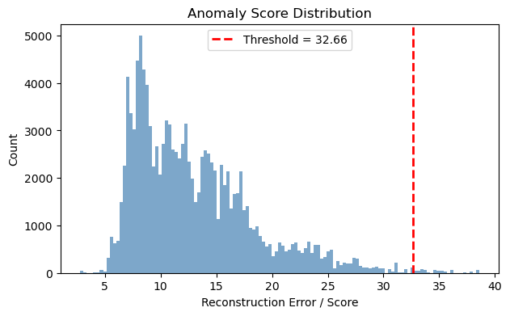

```python
import matplotlib.pyplot as plt

plt.figure(figsize=(7,4), dpi=100)
plt.hist(y_train_scores, bins='auto', color='steelblue', alpha=0.7)
plt.axvline(threshold, color='red', linestyle='--', linewidth=2, label=f"Threshold = {threshold:.2f}")
plt.title("Anomaly Score Distribution")
plt.xlabel("Reconstruction Error / Score")
plt.ylabel("Count")
plt.legend()
plt.show()
```

### The autoencoder model with threshold of 32.66 identifies 612 anomalies in the train dataset. By looking at the top 10 anomalous hospitals, the model suggests certain patterns of anomalies:

### - High cost is not the only factor that signifies anomalies, meaning that the model is flagging issues in features not just large amount of money

### - The severity of the DRGs are mixed including low-severity health issues as well as higher-severity.

### - Especially with the low severity cases, the model suggests potential irregularities in average costs comparing to other DRGs or state averages.

### - There are a wide range of types of hospitals from tertiary centers to community hospitals, suggesting potential outlier patterns within peer groups.

### - Many states appear in the top 10 indicating that there is not a single regional price driver but more provider- or DRG- specific behaviors.

```python
top_anomalies.to_csv("Hospital_Anomalies_Report.csv", index=False)
print(" Anomaly report saved as: Hospital_Anomalies_Report.csv")
```

```
 Anomaly report saved as: Hospital_Anomalies_Report.csv
```

## Ensemble Autoenconder (with Averages)

### An ensemble autoencoder combines the outputs of multiple autoencoders, trained with various architectures, random seeds, or feature subsets, to produce a single, more reliable anomaly score. Each base autoencoder learns to reconstruct normal patterns; their reconstruction errors are then aggregated to form a consensus view of abnormality. This ensemble design reduces the variance and bias of any single model, captures structure in the data, and is more robust to noise in specific features or hospitals, producing an overal more realiable model.

```python
from pyod.models.combination import aom, moa, average, maximization
from pyod.utils.utility import standardizer
from pyod.models.auto_encoder import AutoEncoder
atcdr1 = AutoEncoder(contamination=0.005, hidden_neuron_list =[5, 2])
atcdr2 = AutoEncoder(contamination=0.005, hidden_neuron_list =[10, 2])
atcdr3 = AutoEncoder(contamination=0.005, hidden_neuron_list =[15, 10, 2] )

train_scores = np.zeros([X_train.shape[0], 3])
test_scores = np.zeros([X_test.shape[0], 3])
atcdr1.fit(X_train)
atcdr2.fit(X_train)
atcdr3.fit(X_train)

train_scores[:, 0] = atcdr1.decision_function(X_train)
train_scores[:, 1] = atcdr2.decision_function(X_train)
train_scores[:, 2] = atcdr3.decision_function(X_train)
test_scores[:, 0] = atcdr1.decision_function(X_test)
test_scores[:, 1] = atcdr2.decision_function(X_test)
test_scores[:, 2] = atcdr3.decision_function(X_test)

train_scores_norm, test_scores_norm = standardizer(train_scores,test_scores)
```

```python
combined_train_scores = average(train_scores_norm)
combined_test_scores = average(test_scores_norm)
```

```python
import numpy as np

contamination = 0.005
threshold = np.percentile(combined_train_scores, 100 * (1 - contamination))
print("Threshold value:", threshold)

train_anomaly_labels = (combined_train_scores > threshold).astype(int)
test_anomaly_labels = (combined_test_scores > threshold).astype(int)
```

```
Threshold value: 3.6340810390515252
```

### At 0.5% potential anomalies, the model shows a threshold value of 3.63.

```python
from collections import Counter

print("Train anomalies count:", Counter(train_anomaly_labels))
print("Test anomalies count:", Counter(test_anomaly_labels))
```

```
Train anomalies count: Counter({0: 121686, 1: 612})
Test anomalies count: Counter({0: 40503, 1: 264})
```

```python
merged_train = merged.iloc[X_train.index].copy()
merged_train['Anomaly_Score'] = combined_train_scores
merged_train['Anomaly_Label'] = train_anomaly_labels
```

```python
anomalies = merged_train[merged_train['Anomaly_Label'] == 1]
print("Total anomalies detected:", anomalies.shape[0])
```

```
Total anomalies detected: 612
```

```python
merged_train = merged.iloc[X_train.index].copy()
merged_train['Anomaly_Score'] = combined_train_scores
merged_train['Anomaly_Label'] = train_anomaly_labels
anomalies = merged_train[merged_train['Anomaly_Label'] == 1]
print(f" Total anomalies detected: {anomalies.shape[0]}")
```

```
 Total anomalies detected: 612
```

```python
cols_to_show = [
    'Provider_Name', 'Provider_State', 'DRG',
    'Average_Total_Payments', 'Average_Covered_Charges',
    'Average_Medicare_Payment', 'Anomaly_Score'
]

anomalies_sorted = anomalies[cols_to_show].sort_values('Anomaly_Score', ascending=False)

print("Top anomalous hospitals:")
display(anomalies_sorted.head(15))
```

```
Top anomalous hospitals:
```

|  | Provider_Name | Provider_State | DRG | Average_Total_Payments | Average_Covered_Charges | Average_Medicare_Payment | Anomaly_Score |
| --- | --- | --- | --- | --- | --- | --- | --- |
| 100125 | UNITED HSPTL SYS | WI | 390 - G.I. OBSTRUCTION W/O CC/MCC | 3818.00 | 16398.23 | 3039.23 | 4.702221 |
| 47484 | TUFTS MEDICAL CENTER | MA | 247 - PERC CARDIOVASC PROC W DRUG-ELUTING STEN... | 20064.98 | 36992.34 | 17260.84 | 4.701350 |
| 11024 | CONWAY REGIONAL MEDICAL CENTER | AR | 101 - SEIZURES W/O MCC | 4376.60 | 11108.26 | 2940.26 | 4.700982 |
| 92063 | MAYO CLINIC - SAINT MARYS HOSPITAL | MN | 377 - G.I. HEMORRHAGE W MCC | 17249.88 | 37084.50 | 12396.95 | 4.700443 |
| 120717 | METRO HEALTH MEDICAL CENTER | OH | 536 - FRACTURES OF HIP & PELVIS W/O MCC | 7018.18 | 14828.75 | 5966.93 | 4.700260 |
| 74790 | CAROLINA PINES REGIONAL MEDICAL CENTER | SC | 308 - CARDIAC ARRHYTHMIA & CONDUCTION DISORDER... | 7672.36 | 29259.09 | 6952.00 | 4.700203 |
| 72750 | WENTWORTH-DOUGLASS HOSPITAL | NH | 305 - HYPERTENSION W/O MCC | 3775.14 | 17383.21 | 2730.85 | 4.699556 |
| 114998 | HARTFORD HOSPITAL | CT | 480 - HIP & FEMUR PROCEDURES EXCEPT MAJOR JOIN... | 27450.44 | 74604.05 | 26578.88 | 4.698443 |
| 90200 | BAYHEALTH - KENT GENERAL HOSPITAL | DE | 372 - MAJOR GASTROINTESTINAL DISORDERS & PERIT... | 8343.93 | 27170.13 | 7394.43 | 4.697956 |
| 90949 | SAINT FRANCIS HOSPITAL SOUTH | OK | 372 - MAJOR GASTROINTESTINAL DISORDERS & PERIT... | 6998.58 | 14871.33 | 5270.66 | 4.697810 |
| 58604 | AUGUSTA HEALTH | VA | 286 - CIRCULATORY DISORDERS EXCEPT AMI, W CARD... | 11207.73 | 27263.47 | 10436.57 | 4.697725 |
| 119894 | UNIVERSITY OF WI HOSPITALS & CLINICS AUTHORITY | WI | 491 - BACK & NECK PROC EXC SPINAL FUSION W/O C... | 9432.42 | 21927.45 | 7972.00 | 4.697092 |
| 17991 | PRESBYTERIAN HOSPITAL | NM | 178 - RESPIRATORY INFECTIONS & INFLAMMATIONS W CC | 9187.02 | 24535.32 | 8426.92 | 4.696244 |
| 78212 | ST ELIZABETH HOSPITAL | IL | 310 - CARDIAC ARRHYTHMIA & CONDUCTION DISORDER... | 3355.49 | 11205.47 | 2107.52 | 4.695478 |
| 41859 | GLENS FALLS HOSPITAL | NY | 208 - RESPIRATORY SYSTEM DIAGNOSIS W VENTILATO... | 12970.71 | 33870.26 | 12099.37 | 4.695029 |

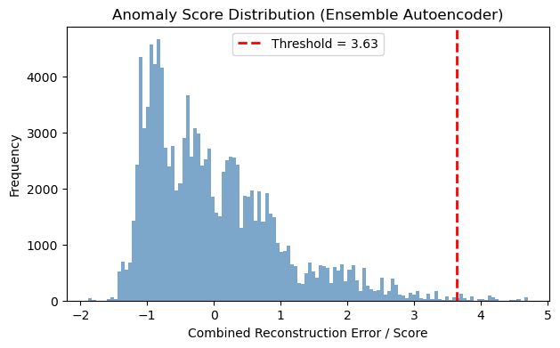

```python
import matplotlib.pyplot as plt

plt.figure(figsize=(7,4), dpi=100)
plt.hist(combined_train_scores, bins='auto', color='steelblue', alpha=0.7)
plt.axvline(threshold, color='red', linestyle='--', linewidth=2, label=f"Threshold = {threshold:.2f}")
plt.title("Anomaly Score Distribution (Ensemble Autoencoder)")
plt.xlabel("Combined Reconstruction Error / Score")
plt.ylabel("Frequency")
plt.legend()
plt.show()
```

[figure not shown]

```python
top30 = anomalies_sorted.head(30)

plt.figure(figsize=(10,5))
plt.barh(top30['Provider_Name'], top30['Anomaly_Score'], color='firebrick')
plt.gca().invert_yaxis()
plt.title("Top 10 Most Anomalous Hospitals (Autoencoder Ensemble)")
plt.xlabel("Anomaly Score (Reconstruction Error)")
plt.ylabel("Hospital Name")
plt.show()
```

## Ensemble autoencoders with assumed 0.5% potential anomalous cases, identifies 612 anomalies in the train data set at a threshold of 3.63. These anomolous cases provide certian insights:

### - Similar with the anomolous cases in autoencoders, flagged cases are not defined solely by high total payments; the model responds to unusual combinations of features, including engineered ratios.

### - Anomalies occur across both low-severity and high-severity DRGs, indicating potential coding or utilization irregularities.

### - The top anomalies include DRG 247 (PCI with drug-eluting stent) and DRG 480 (hip and femur procedures), where implant and pass-through pricing can create variation.

### - Anomalies appear across multiple states and provider types, suggesting provider- or DRG-specific drivers rather than a single regional effect.

```python
anomalies_sorted.to_csv("Hospital_Anomaly_Report_Ensemble.csv", index=False)
print(" Saved report: Hospital_Anomaly_Report_Ensemble.csv")
```

```
 Saved report: Hospital_Anomaly_Report_Ensemble.csv
```

# Variational Autoencoders

### Variational Autoencoders (VAEs) are a machine learning technique used to learn the underlying distribution of normal data by compressing and reconstructing it. By encoding input data into a lower-dimensional latent space and then decoding it back, the model learns to represent typical structures and relationships within the dataset. Unlike traditional Autoencoders (AEs), VAEs construct the latent space using two layers that represent the mean and the logarithm of the variance of a probability distribution, combined with a small amount of random noise. As a result, each reconstruction is slightly different, enabling the model to explore the entire latent space and generate diverse outputs. This probabilistic framework allows the VAE to capture uncertainty and variation in the data, making it particularly effective for detecting subtle or complex irregularities, where deviations from learned patterns manifest as higher reconstruction errors, indicating potential anomalies.

```python
print("Checking data quality...")
print(f"X_train_pd - NaN count: {X_train_pd.isna().sum().sum()}")
print(f"X_train_pd - Inf count: {np.isinf(X_train_pd.values).sum()}")
print(f"X_train_pd - Shape: {X_train_pd.shape}")
print(f"X_train_pd - Min: {X_train_pd.values.min():.4f}, Max: {X_train_pd.values.max():.4f}")
```

```
Checking data quality...
X_train_pd - NaN count: 0
X_train_pd - Inf count: 0
X_train_pd - Shape: (122298, 200)
X_train_pd - Min: -17.6953, Max: 22.5628
```

```python
from sklearn.feature_selection import VarianceThreshold
from sklearn.impute import SimpleImputer

vt = VarianceThreshold(threshold=0.0)
vt.fit(X_train_pd)
keep_cols = X_train_pd.columns[vt.get_support()]
X_train_pd = X_train_pd[keep_cols]
if 'X_test_pd' in globals():
    X_test_pd = X_test_pd[keep_cols]

X_train_pd = X_train_pd.replace([np.inf, -np.inf], np.nan)
if 'X_test_pd' in globals():
    X_test_pd = X_test_pd.replace([np.inf, -np.inf], np.nan)

imputer = SimpleImputer(strategy='mean')   # or 'median'
X_train_np = imputer.fit_transform(X_train_pd).astype('float32')
if 'X_test_pd' in globals():
    X_test_np = imputer.transform(X_test_pd).astype('float32')

assert np.isfinite(X_train_np).all(), "Train still has non-finite values"
if 'X_test_pd' in globals():
    assert np.isfinite(X_test_np).all(), "Test still has non-finite values"

from pyod.models.vae import VAE
vae_model = VAE(
    contamination=0.005,
    preprocessing=True,
    verbose=1,
    random_state=42
)
vae_model.fit(X_train_np)
```

```python
y_train_pred = vae_model.labels_
y_train_scores = vae_model.decision_scores_
```

```python
y_test_pred = vae_model.predict(X_test_np)
y_test_scores = vae_model.decision_function(X_test_np)
```

```python
print("\n" + "="*50)
print("VAE Anomaly Detection Results")
print("="*50)

print(f"\nTraining Set:")
print(f"Total samples: {len(y_train_pred)}")
print(f"Normal samples: {np.sum(y_train_pred == 0)}")
print(f"Anomalies detected: {np.sum(y_train_pred == 1)}")
print(f"Contamination rate: {np.sum(y_train_pred == 1) / len(y_train_pred):.4f}")

print(f"\nTest Set:")
print(f"Total samples: {len(y_test_pred)}")
print(f"Normal samples: {np.sum(y_test_pred == 0)}")
print(f"Anomalies detected: {np.sum(y_test_pred == 1)}")
print(f"Contamination rate: {np.sum(y_test_pred == 1) / len(y_test_pred):.4f}")

print(f"\nDecision threshold: {vae_model.threshold_:.4f}")

print(f"\nAnomaly Score Statistics (Test Set):")
print(f"Mean: {np.mean(y_test_scores):.4f}")
print(f"Std: {np.std(y_test_scores):.4f}")
print(f"Min: {np.min(y_test_scores):.4f}")
print(f"Max: {np.max(y_test_scores):.4f}")
```

```
==================================================
VAE Anomaly Detection Results
==================================================

Training Set:
Total samples: 122298
Normal samples: 121686
Anomalies detected: 612
Contamination rate: 0.0050

Test Set:
Total samples: 40767
Normal samples: 40502
Anomalies detected: 265
Contamination rate: 0.0065

Decision threshold: 32.2131

Anomaly Score Statistics (Test Set):
Mean: 12.5798
Std: 5.5995
Min: 2.1850
Max: 39.0445
```

```python
train_results = pd.DataFrame({
        'Anomaly_Score': y_train_scores,
        'Anomaly_Label': y_train_pred,
        'Dataset': 'Train'
    }, index=X_train_pd.index)

test_results = pd.DataFrame({
        'Anomaly_Score': y_test_scores,
        'Anomaly_Label': y_test_pred,
        'Dataset': 'Test'
    }, index=X_test_pd.index)
```

```python
all_results = pd.concat([train_results, test_results])
```

```python
merged_with_anomalies = merged.join(all_results, how='inner')
```

```python
anomalies_df = merged_with_anomalies[merged_with_anomalies['Anomaly_Label'] == 1]
normal_df = merged_with_anomalies[merged_with_anomalies['Anomaly_Label'] == 0]
```

```python
print(f"\n" + "="*50)
print("MERGED DATA WITH ANOMALY DETECTION")
print("="*50)
print(f"\nTotal records: {len(merged_with_anomalies)}")
print(f"Normal cases: {len(normal_df)}")
print(f"Anomalies: {len(anomalies_df)}")
```

```
==================================================
MERGED DATA WITH ANOMALY DETECTION
==================================================

Total records: 163065
Normal cases: 162188
Anomalies: 877
```

```python
print(f"\nTop 15 Anomalies with Provider Information:")
if len(anomalies_df) > 0:
        top_anomalies = anomalies_df.nlargest(15, 'Anomaly_Score')[
            ['Provider_Name', 'Provider_Id', 'Provider_City', 'Provider_State',
             'DRG', 'Average_Total_Payments', 'Anomaly_Score', 'Dataset']
        ]
        print(top_anomalies.to_string())
else:
        print("No anomalies detected")
```

```
Top 15 Anomalies with Provider Information:
                                      Provider_Name Provider_Id    Provider_City Provider_State                                                         DRG  Average_Total_Payments  Anomaly_Score Dataset
3685                             ST THOMAS HOSPITAL      440082        NASHVILLE             TN  064 - INTRACRANIAL HEMORRHAGE OR CEREBRAL INFARCTION W MCC                 9951.00      39.044491    Test
739                    RIVERSIDE METHODIST HOSPITAL      360006         COLUMBUS             OH                    039 - EXTRACRANIAL PROCEDURES W/O CC/MCC                 6823.81      39.018990    Test
3819                RUTLAND REGIONAL MEDICAL CENTER      470005          RUTLAND             VT  064 - INTRACRANIAL HEMORRHAGE OR CEREBRAL INFARCTION W MCC                13826.47      39.017696    Test
20674                     ROUND ROCK MEDICAL CENTER      450718       ROUND ROCK             TX                 189 - PULMONARY EDEMA & RESPIRATORY FAILURE                 7939.93      39.015831    Test
17492              GENESIS MEDICAL CENTER-DAVENPORT      160033        DAVENPORT             IA           178 - RESPIRATORY INFECTIONS & INFLAMMATIONS W CC                 8179.31      39.012447    Test
29091       SIERRA VISTA REGIONAL HEALTH CENTER INC       30043     SIERRA VISTA             AZ                     193 - SIMPLE PNEUMONIA & PLEURISY W MCC                11269.20      39.012341    Test
14450                  ALBEMARLE HOSPITAL AUTHORITY      340109   ELIZABETH CITY             NC                            176 - PULMONARY EMBOLISM W/O MCC                 7514.84      39.009174    Test
16990               SAINT FRANCIS MEMORIAL HOSPITAL       50152    SAN FRANCISCO             CA           178 - RESPIRATORY INFECTIONS & INFLAMMATIONS W CC                17925.96      39.008385    Test
3772             CLEAR LAKE REGIONAL MEDICAL CENTER      450617          WEBSTER             TX  064 - INTRACRANIAL HEMORRHAGE OR CEREBRAL INFARCTION W MCC                11535.08      39.007904    Test
20405  EXCELA HEALTH WESTMORELAND REGIONAL HOSPITAL      390145       GREENSBURG             PA                 189 - PULMONARY EDEMA & RESPIRATORY FAILURE                 6901.82      39.004276    Test
25959                        NIX HEALTH CARE SYSTEM      450130      SAN ANTONIO             TX            191 - CHRONIC OBSTRUCTIVE PULMONARY DISEASE W CC                 7304.00      39.002594    Test
853                           RHODE ISLAND HOSPITAL      410007       PROVIDENCE             RI                    039 - EXTRACRANIAL PROCEDURES W/O CC/MCC                 9262.11      38.996616    Test
17202                       HOLY CROSS HOSPITAL INC      100073  FORT LAUDERDALE             FL           178 - RESPIRATORY INFECTIONS & INFLAMMATIONS W CC                 8543.28      38.995804    Test
25520                               BERGER HOSPITAL      360170      CIRCLEVILLE             OH            191 - CHRONIC OBSTRUCTIVE PULMONARY DISEASE W CC                 6523.97      38.986530    Test
15908              ANDERSON REGIONAL MEDICAL CENTER      250104         MERIDIAN             MS          177 - RESPIRATORY INFECTIONS & INFLAMMATIONS W MCC                11363.24      38.945175    Test
```

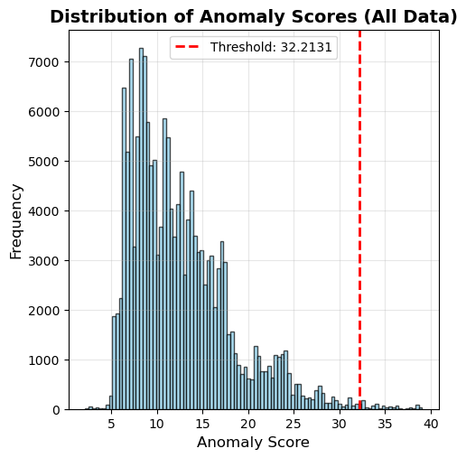

```python
fig = plt.figure(figsize=(18, 12))
ax1 = plt.subplot(2, 3, 1)
plt.hist(merged_with_anomalies['Anomaly_Score'], bins=100, alpha=0.7,
         color='skyblue', edgecolor='black')
plt.axvline(vae_model.threshold_, color='red', linestyle='--', linewidth=2,
                label=f'Threshold: {vae_model.threshold_:.4f}')
plt.xlabel('Anomaly Score', fontsize=12)
plt.ylabel('Frequency', fontsize=12)
plt.title('Distribution of Anomaly Scores (All Data)', fontsize=14, fontweight='bold')
plt.legend()
plt.grid(True, alpha=0.3)
```

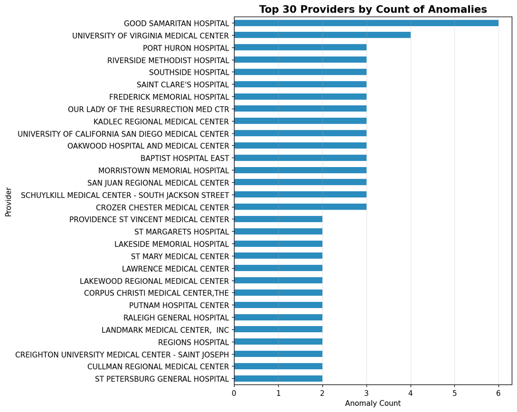

```python
anoms = merged_with_anomalies[merged_with_anomalies['Anomaly_Label'] == 1].copy()

anoms['Provider_Name'] = anoms['Provider_Name'].fillna(anoms.get('Provider_Id'))

top30 = (
    anoms.groupby('Provider_Name')
         .size()
         .sort_values(ascending=False)
         .head(30)
)

plt.figure(figsize=(10, 8), dpi=110)
top30.sort_values(ascending=True).plot(kind='barh', color='#2b8cbe')
plt.title('Top 30 Providers by Count of Anomalies', fontsize=14, fontweight='bold')
plt.xlabel('Anomaly Count')
plt.ylabel('Provider')
plt.grid(axis='x', alpha=0.3)
plt.tight_layout()
plt.show()
```

```python
top30.to_csv('Top30_Providers_Anomaly_Counts.csv', header=['Anomaly_Count'])
print('Saved: Top30_Providers_Anomaly_Counts.csv')
```

```
Saved: Top30_Providers_Anomaly_Counts.csv
```

## VAEs model with 0.5% assumed anomalies identifies 612 anomalies in the train dataset and 877 in total. The top anomalies provide some insights:

### - Similar to autoencoder models, the VAE model flags observations that deviate from the learned normal distribution, not simply high-dollar cases, indicating atypical feature combinations across payment ratios, discharges, and engineered features.

### - Anomalies span both low-severity and high-severity DRGs (e.g., intracranial hemorrhage with MCC, extracranial procedures, pulmonary edema, respiratory infections, simple pneumonia), suggesting potential irregular charges among DRGs.

### - Concentrations by provider show provider- or DRG-specific drivers rather than a single regional effect.